# Lab06: ANOVA

# Your mission should you choose to accept it…

Three years ago, late in April of 2017 a zombie outbreak hit North America! You are one of the few lucky survivors and have been tasked with a statistical study of the trends and patterns of the Zombie outbreak. You will use basic statistics and plots to help inform the management of this viral outbreak. The world is counting on your ability to synthesize the data from the most infected cities. Beware a type 1 error here could be deadly!

# Chunk 1: Load libraries and Dataset

1. load any tidyverse
2. load the Zombie data set
3. which variables a numeric? Which variables are categorical?
4. What is the structure of the dataset?

```
## 'data.frame':    50 obs. of  17 variables:
##  $ City                 : Factor w/ 50 levels "Appleton","Atlanta",..: 7 49 36 42 23 41 46 5 15 34 ...
##  $ Country              : Factor w/ 3 levels "Canada","Mexico",..: 3 1 3 3 3 3 2 1 1 3 ...
##  $ Lat                  : num  36 49.2 45.5 37.7 34 ...
##  $ Lon                  : num  -78.5 -123.1 -122.7 -122.5 -118.2 ...
##  $ Marshall_Law_Enforced: Factor w/ 2 levels "N","Y": 2 1 2 1 1 2 1 1 1 1 ...
##  $ Z_Vaccine_Deployed   : Factor w/ 2 levels "N","Y": 2 2 2 2 2 2 2 2 2 2 ...
##  $ Zombie_Behavior      : Factor w/ 3 levels "Average","Fast",..: 2 3 3 1 2 2 2 3 3 2 ...
##  $ deomographic         : Factor w/ 4 levels "Adults","Children",..: 2 1 3 1 1 1 3 4 4 3 ...
##  $ Majority_Z_ethnicity : Factor w/ 3 levels "African_American",..: 2 2 3 2 3 3 3 2 2 2 ...
##  $ Mean_Temp            : num  25 2 5 10 13 22 23 -1.5 -2 21 ...
##  $ Mean_Precip          : int  838 2100 1999 890 756 250 230 1791 1990 300 ...
##  $ Population           : num  0.0482 2.1 0.632 0.827 13.9 ...
##  $ Reported_Incidents   : int  10091 999 311233 83101 2712311 719812 73281 199 391 8139 ...
##  $ YearReported         : int  2019 2020 2020 2020 2020 2020 2020 2020 2020 2019 ...
##  $ Percent_Infected     : num  20.94 0.0476 49.2457 10.0485 19.513 ...
##  $ Percent_Immune       : num  33 1.8 25 32.3 27.9 ...
##  $ Status_unknown       : num  46.1 98.2 25.7 57.6 52.6 ...
```

# Chunk 2: Check for normality in the response variables

1. Use two different methids to graphically test for nomrality in the Mean_Temp and Mean_Precip variables grouped by Country.
2. Do Mean_Temp and Mean_Precip appear to be normally distributed? Are any outliers detected? If so where?
3. Mathematically test for normality in Percent_Infected and the Percen_Immune variables? Are these variables normally distributed?
4. If Percent_Infected and the Percen_Immune variables are not normal, attempt a transformation and test whether the distribution has improved?

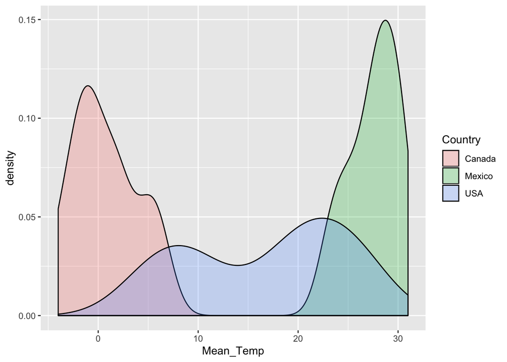

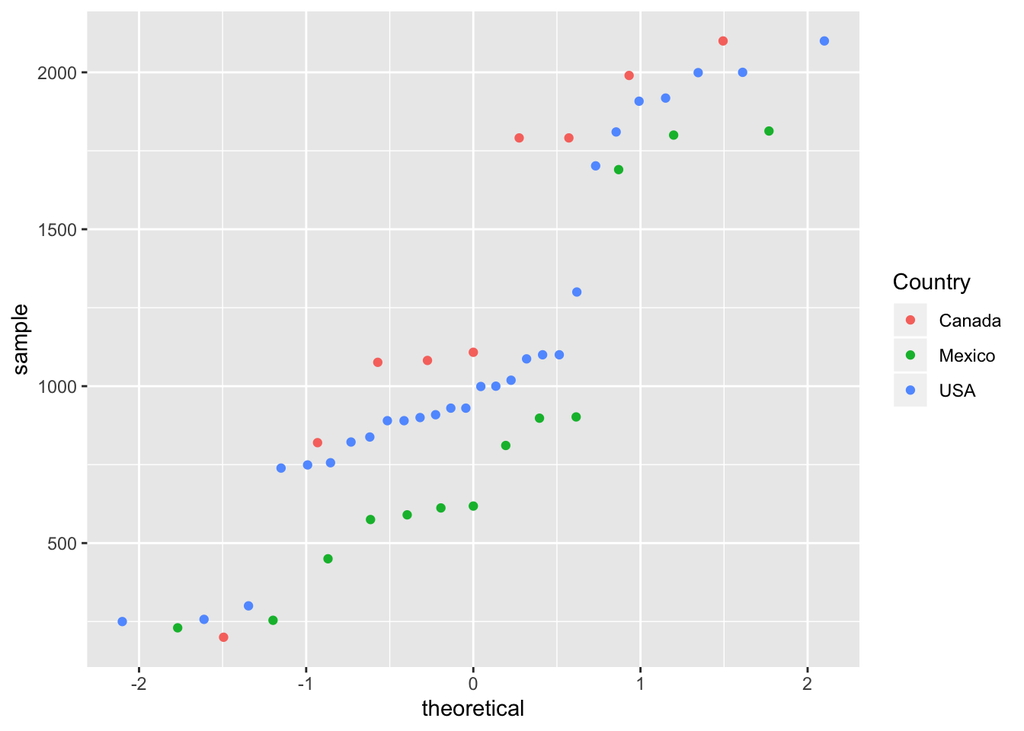

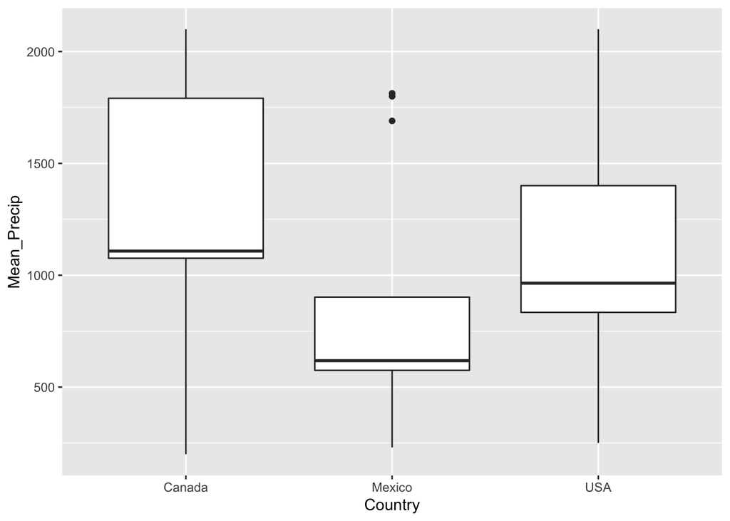

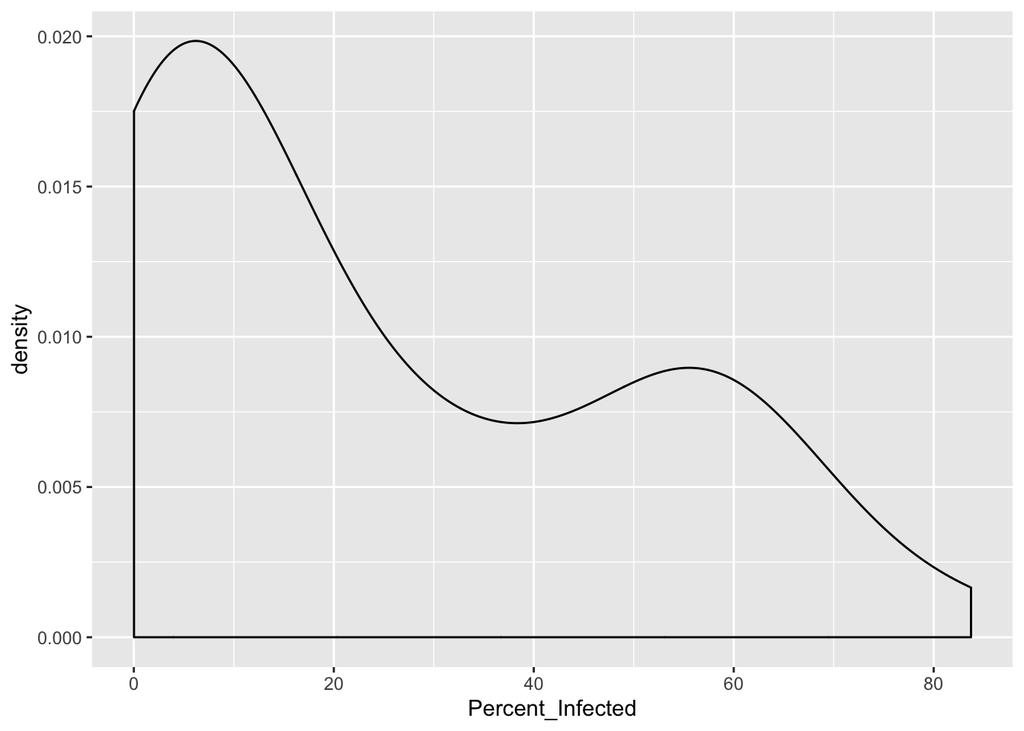

```
##
##  Shapiro-Wilk normality test
##
## data:  Zombie$Percent_Infected
## W = 0.86314, p-value = 3.581e-05
```

```
##
##  Shapiro-Wilk normality test
##
## data:  Zombie$log.pi
## W = 0.83369, p-value = 5.757e-06
```

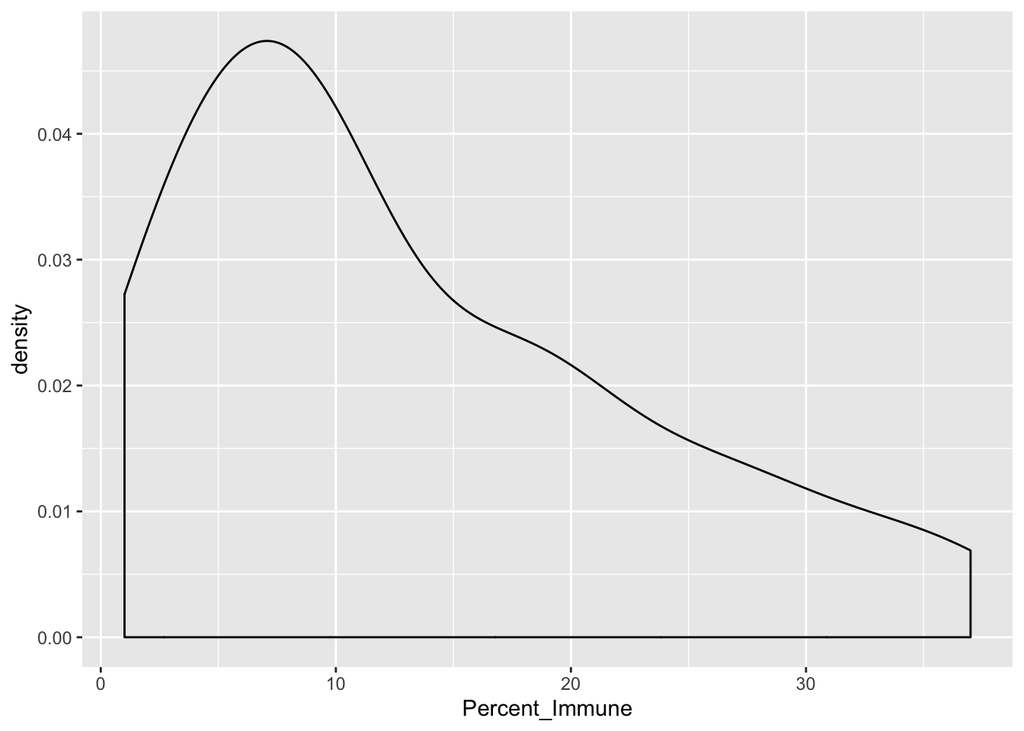

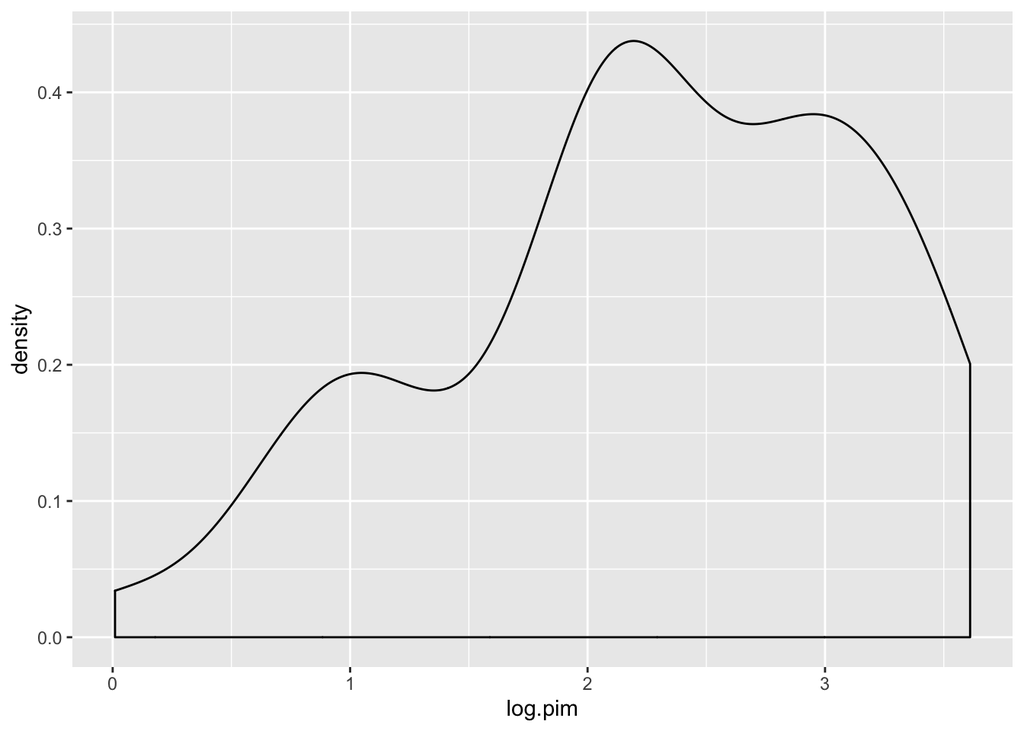

```
##
##  Shapiro-Wilk normality test
##
## data:  Zombie$log.pim
## W = 0.95743, p-value = 0.06936
```

# Chunk 3: Comparison of means: Graphically

```
## # A tibble: 3 x 5
##   Majority_Z_ethnicity mean.infected se.infected upper.95 lower.95
##   <fct>                        <dbl>       <dbl>    <dbl>    <dbl>
## 1 African_American              26.8        8.42     43.3     10.3
## 2 Caucasian                     23.2        5.22     33.4     13.0
## 3 Latino                        26.0        5.76     37.3     14.7
```

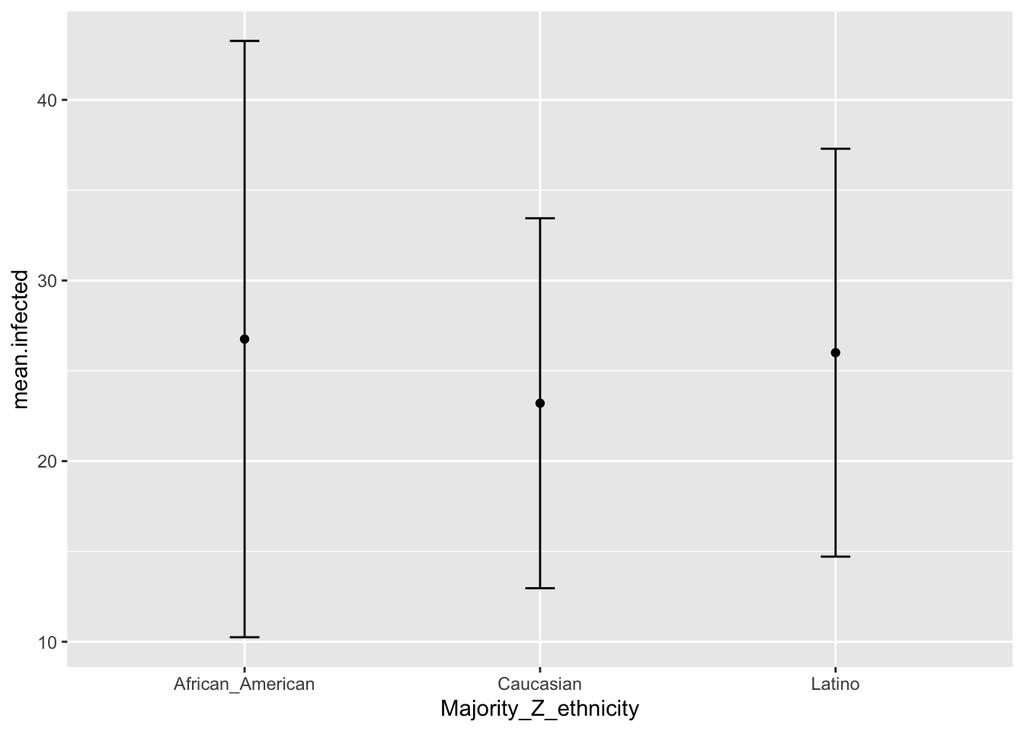

```
## # A tibble: 4 x 5
##   deomographic mean.infected se.infected upper.95  lower.95
##   <fct>                <dbl>       <dbl>    <dbl>     <dbl>
## 1 Adults              9.33        4.15     17.5    1.20
## 2 Children           38.1         5.44     48.7   27.4
## 3 Seniors            24.4         6.06     36.3   12.5
## 4 Young Adults        0.0528      0.0267    0.105  0.000480
```

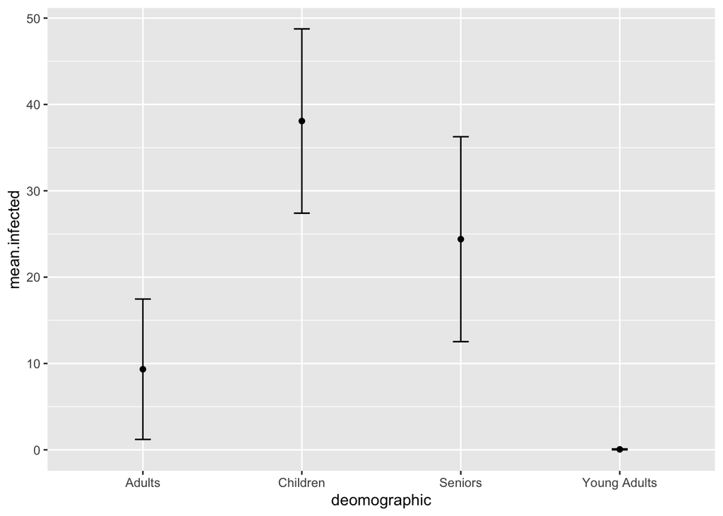

# Chunk 4: Comparison of means: Statistically

1. ```
   Statistically test if there are differences in the means of the ethnicity and age demographics and the percent infected? Explain the results in reference to the hypotheses being tested
   ```

2. ```
   Use a post-hoc test to evaluate where significant differences exist? Explain your results
   ```

3. ```
   Graphically display the results of the tukey test.
   ```

4. Interpret your results in terms of statistical and biological hypotheses testing.

```
##                      Df Sum Sq Mean Sq F value Pr(>F)
## Majority_Z_ethnicity  2    115    57.7   0.092  0.912
## Residuals            47  29392   625.4
```

```
##              Df Sum Sq Mean Sq F value  Pr(>F)
## deomographic  3   8651  2883.7    6.36 0.00107 **
## Residuals    46  20857   453.4
## ---
## Signif. codes:  0 '***' 0.001 '**' 0.01 '*' 0.05 '.' 0.1 ' ' 1
```

```
##   Tukey multiple comparisons of means
##     95% family-wise confidence level
##
## Fit: aov(formula = Percent_Infected ~ deomographic, data = Zombie)
##
## $deomographic
##                             diff        lwr       upr     p adj
## Children-Adults        28.743479   8.713506 48.773453 0.0021488
## Seniors-Adults         15.062185  -7.199886 37.324256 0.2848572
## Young Adults-Adults    -9.280956 -45.634766 27.072853 0.9039819
## Seniors-Children      -13.681294 -33.711268  6.348679 0.2769335
## Young Adults-Children -38.024436 -73.055843 -2.993028 0.0286550
## Young Adults-Seniors  -24.343141 -60.696951 12.010668 0.2935668
```

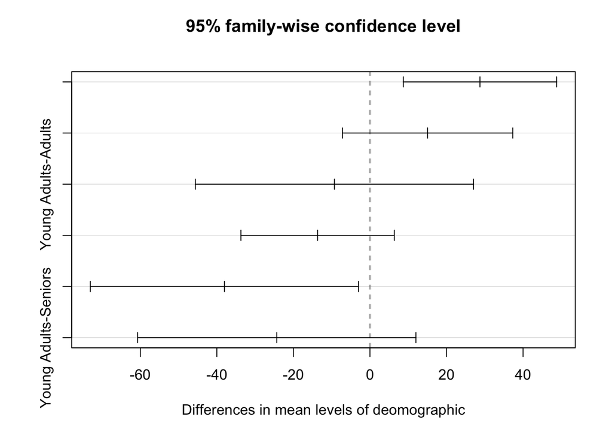

# Chunk 5: Non-parametric alternatives

You suspect that environmental conditions can influence the behavior of zombies. Unfortunately, the Mean_Temp variable is not easily transformed, and parametric tests cannot be used to evaluate differences in means. A) What is H0 and HA being tested? B) Use a non-parametric alternative test to evaluate if temperature affects zombie behavior. C) Plot your results as a boxplot D) What do you suspect can be driving the pattern you observe? Use a biological explanation for this phenomenon.

```
##
##  Kruskal-Wallis rank sum test
##
## data:  Mean_Temp by Zombie_Behavior
## Kruskal-Wallis chi-squared = 35.144, df = 2, p-value = 2.336e-08
```

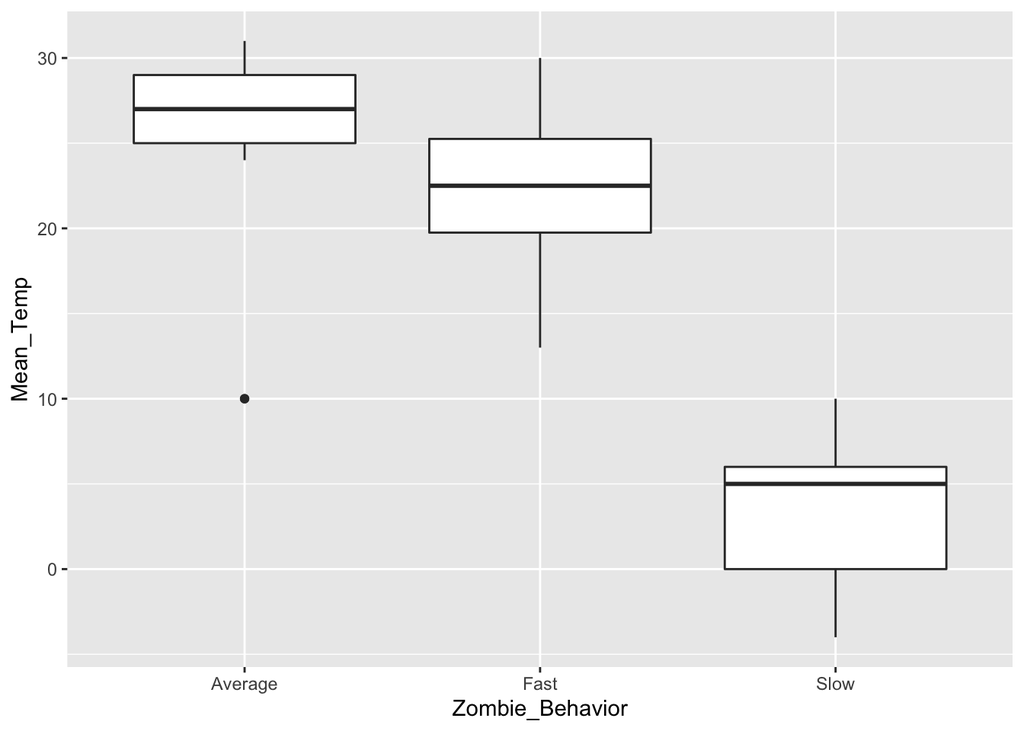